# An Introduction to Statistical Learning (2013)

Solutions to Applied Exercises

by Brian Hassett

# Chapter 8 Tree-Based Methods

This notebook is a rough outline of solutions to the applied exercises in Chapter 8 of **An Introduction to Statistical Learning** (James et al. (2013)[^1]).

## Setup

```r
library(ISLR)
library(glmnet)
library(leaps)
library(pls)
library(randomForest)
library(ggdendro)
library(MASS)
library(tree)
library(pls)
library(gbm)
library(class)
library(tidyverse)
library(patchwork)
theme_set(theme_bw())

# Load my functions:
source("/home/brian/R/dir/Util/bh_functions.R")

# Given a filename, return the filepath. Default folder is the `data` folder in the current working directory.
get_path <- function(filename) {
  str_c(getwd(), "data", filename, sep = "/")
}

# Colors:
ISLR_blue <- "#176FC0"
ISLR_brown <- "#94340E"
ISLR_lightblue <- "#68A5DB"
ISLR_orange <- "#CC5318"

# Return vector of the names of numeric columns in a data frame:
numeric_cols <- function(df) {
  is_numeric_cols <- map_lgl(df, is.numeric)
  return(names(df)[is_numeric_cols])
}

# predict() function for regsubsets() as given in the book:
predict.regsubsets <- function(object, newdata, id,...) {
  form <- as.formula(object$call[[2]])
  mat <- model.matrix(form, newdata)
  coefi <- coef(object, id=id)
  xvars <- names(coefi)
  mat[, xvars]%*%coefi
}
```

## Exercise 7

### (a)

View data:

```r
Boston
```

|  | crim | zn | indus | chas | nox | rm | age | dis | rad | tax | ptratio | black | lstat | medv |
| --- | --- | --- | --- | --- | --- | --- | --- | --- | --- | --- | --- | --- | --- | --- |
| 1 | 0.00632 | 18.0 | 2.31 | 0 | 0.5380 | 6.575 | 65.2 | 4.0900 | 1 | 296 | 15.3 | 396.90 | 4.98 | 24.0 |
| 2 | 0.02731 | 0.0 | 7.07 | 0 | 0.4690 | 6.421 | 78.9 | 4.9671 | 2 | 242 | 17.8 | 396.90 | 9.14 | 21.6 |
| 3 | 0.02729 | 0.0 | 7.07 | 0 | 0.4690 | 7.185 | 61.1 | 4.9671 | 2 | 242 | 17.8 | 392.83 | 4.03 | 34.7 |
| 4 | 0.03237 | 0.0 | 2.18 | 0 | 0.4580 | 6.998 | 45.8 | 6.0622 | 3 | 222 | 18.7 | 394.63 | 2.94 | 33.4 |
| 5 | 0.06905 | 0.0 | 2.18 | 0 | 0.4580 | 7.147 | 54.2 | 6.0622 | 3 | 222 | 18.7 | 396.90 | 5.33 | 36.2 |
| 6 | 0.02985 | 0.0 | 2.18 | 0 | 0.4580 | 6.430 | 58.7 | 6.0622 | 3 | 222 | 18.7 | 394.12 | 5.21 | 28.7 |
| 7 | 0.08829 | 12.5 | 7.87 | 0 | 0.5240 | 6.012 | 66.6 | 5.5605 | 5 | 311 | 15.2 | 395.60 | 12.43 | 22.9 |
| 8 | 0.14455 | 12.5 | 7.87 | 0 | 0.5240 | 6.172 | 96.1 | 5.9505 | 5 | 311 | 15.2 | 396.90 | 19.15 | 27.1 |
| 9 | 0.21124 | 12.5 | 7.87 | 0 | 0.5240 | 5.631 | 100.0 | 6.0821 | 5 | 311 | 15.2 | 386.63 | 29.93 | 16.5 |
| 10 | 0.17004 | 12.5 | 7.87 | 0 | 0.5240 | 6.004 | 85.9 | 6.5921 | 5 | 311 | 15.2 | 386.71 | 17.10 | 18.9 |

[output cut: 496 more lines]

Fit random forests on the data for a range of values of `ntree` and `mtry`:

```r
set.seed(1)

M <- c(4, 6, 8, 10)
N.tree <- seq(5, 525, by = 5)

train <- sample(1:nrow(Boston), nrow(Boston)/2)

## List of random forests:
rfs <- map(M, function(m)
          map(N.tree, function(n) {
            if(n %% 100 == 0) print(str_c("m: ", m, "; n: ", n, " ..."))
            randomForest(medv ~ ., data = Boston[train, ], mtry = m, ntree = n)
            })
          )

## List of predictions for each random forest:
yhat.rfs <- map(rfs, function(rf_list) {
  map(rf_list, function(rf) {
    predict(rf, newdata = Boston[-train, ])
  })
})
#yhat.rfs[[1]][[1]] - predict(rfs[[1]][[1]], newdata = Boston[-train, ]) # test

## List of test MSE's for each random forest:
y.test <- Boston[-train, "medv"]
MSE <- map(yhat.rfs, function(yhat_list) {
  map(yhat_list, function(yhat) {
    mean((as_vector(yhat) - y.test)^2)
  })
})
#mean((yhat.rfs[[3]][[2]] - y.test)^2) - MSE[[3]][[2]] # test

# Generate matrix of MSE's:
MSE_matrix <- matrix(NA, nrow = length(N.tree), ncol = length(M))
for(i in 1:length(M)) {
  MSE_matrix[ , i] <- as_vector(MSE[[i]])
}

# Convert to long format for plotting:
MSE_df <- MSE_matrix %>%
  data.frame() %>%
  set_names(as.character(M)) %>%
  mutate(n_tree = N.tree) %>%
  pivot_longer(cols = `4`:`10`, names_to = "mtry", values_to = "MSE") %>%
  mutate(mtry = str_replace(mtry, "X", ""))

# Cache the results:
#saveRDS(MSE_df, "/home/brian/R/dir/ISLR_2/clean/data/MSE_df.RDS")
```

Plot the MSE for each value of `mtry` and `ntree`:

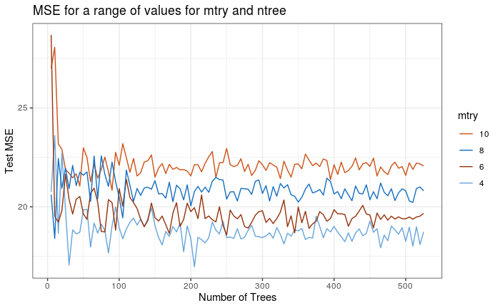

```r
# Read in cached results:
MSE_df <- readRDS("/home/brian/R/dir/ISLR_2/clean/data/MSE_df.RDS")

colors <- c(ISLR_orange, ISLR_blue, ISLR_brown, ISLR_lightblue)
MSE_df %>%
  ggplot() +
  geom_line(aes(n_tree, MSE, color = mtry)) +
  theme_bw() +
  scale_color_manual(breaks = rev(unique(MSE_df$mtry)),
                     values = colors) +
  labs(x = "Number of Trees", y = "Test MSE",
       title = "MSE for a range of values for mtry and ntree")
```

## Exercise 8

View data:

```r
Carseats
```

|  | Sales | CompPrice | Income | Advertising | Population | Price | ShelveLoc | Age | Education | Urban | US |
| --- | --- | --- | --- | --- | --- | --- | --- | --- | --- | --- | --- |
| 1 | 9.50 | 138 | 73 | 11 | 276 | 120 | Bad | 42 | 17 | Yes | Yes |
| 2 | 11.22 | 111 | 48 | 16 | 260 | 83 | Good | 65 | 10 | Yes | Yes |
| 3 | 10.06 | 113 | 35 | 10 | 269 | 80 | Medium | 59 | 12 | Yes | Yes |
| 4 | 7.40 | 117 | 100 | 4 | 466 | 97 | Medium | 55 | 14 | Yes | Yes |
| 5 | 4.15 | 141 | 64 | 3 | 340 | 128 | Bad | 38 | 13 | Yes | No |
| 6 | 10.81 | 124 | 113 | 13 | 501 | 72 | Bad | 78 | 16 | No | Yes |
| 7 | 6.63 | 115 | 105 | 0 | 45 | 108 | Medium | 71 | 15 | Yes | No |
| 8 | 11.85 | 136 | 81 | 15 | 425 | 120 | Good | 67 | 10 | Yes | Yes |
| 9 | 6.54 | 132 | 110 | 0 | 108 | 124 | Medium | 76 | 10 | No | No |
| 10 | 4.69 | 132 | 113 | 0 | 131 | 124 | Medium | 76 | 17 | No | Yes |

[output cut: 390 more lines]

### (a)

Split the data set into a training set and a test set:

```r
### Data:
data <- Carseats
print(str_c(1:ncol(data), ": ", names(data)))
```

```
 [1] "1: Sales"       "2: CompPrice"   "3: Income"      "4: Advertising" "5: Population"  "6: Price"       "7: ShelveLoc"
 [8] "8: Age"         "9: Education"   "10: Urban"      "11: US"
```

```r
y.index = 1 # column index of response variable

X <- data[ , -c(y.index)]
y <- data[, y.index]
names(y) <- names(data)[y.index]
n = nrow(X)
p = ncol(X)
#var.names <- names(X)
df <- data.frame(X, y) # data.frame for use in modeling

### Train/Test:
set.seed(1)
train <- sample(n, n/2) # 50%/50% train/test
test <- (-train)

### Test Error:
MSE <- c()
```

### (b)

Fit a regression tree to the training set:

```r
tree1 <- tree(y ~ ., data = df, subset = train)
summary(tree1)
```

```
Regression tree:
tree(formula = y ~ ., data = df, subset = train)
Variables actually used in tree construction:
[1] "ShelveLoc"   "Price"       "Age"         "Advertising" "CompPrice"   "US"
Number of terminal nodes:  18
Residual mean deviance:  2.167 = 394.3 / 182
Distribution of residuals:
    Min.  1st Qu.   Median     Mean  3rd Qu.     Max.
-3.88200 -0.88200 -0.08712  0.00000  0.89590  4.09900
```

Plot tree:

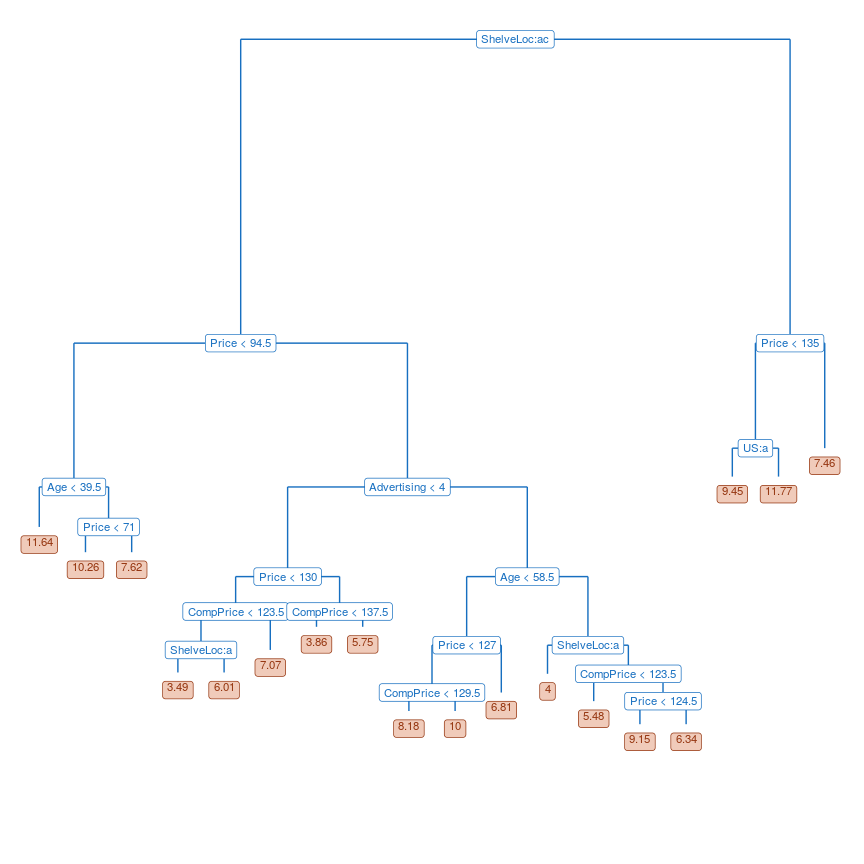

```r
# Use ggdendro to extract the tree data:
# Ref: http://andrie.github.io/ggdendro/
tree1_data <- dendro_data(tree1)

# The above functions doesn't fully extract the splits, so I need to do this separately:
# (This code isn't perfect, especially with factors)
# Full data frame of tree data:
tree1_nodes <- data.frame(
  var = tree1$frame$var,
  n = tree1$frame$n,
  dev = tree1$frame$dev,
  yval = tree1$frame$yval,
  splits = tree1$frame$splits
) %>%
  mutate(`cutleft (<)` = str_replace(splits.cutleft, "<", ""),
         `cutright (>)` = str_replace(splits.cutright, ">", "")) %>%
  dplyr::select(-splits.cutleft, -splits.cutright)

# Extract the labels:
labels <- tree1_nodes %>%
  filter(var != "<leaf>") %>%
  mutate(label = ifelse(!str_detect(`cutleft (<)`, "[A-Za-z]"),
                         str_c(var, " < ", `cutleft (<)`),
                         str_c(var, "", `cutleft (<)`)))%>%
  select(label)

# Replace the labels with the new ones that include the splits:
tree1_data$labels$label <- labels[[1]]

# Plot:
ggplot() +
  geom_segment(data = segment(tree1_data),
               aes(x = x, y = y, xend = xend, yend = yend),
               color = ISLR_blue
  ) +
  geom_label(data = label(tree1_data),
            aes(x = x, y = y, label = label, hjust = 0.5, vjust = ),
            size = 3, fill = "white", color = ISLR_blue, alpha = 1
  ) +
  geom_label(data = leaf_label(tree1_data),
            aes(x = x, y = y, label = label, hjust = 0.5, vjust = 1.5),
            size = 3, fill = ISLR_orange, color = ISLR_brown, alpha = 0.3
  ) +
  coord_cartesian(ylim = c(700, NA)) + # could automate this
  theme_void() +
  theme(plot.title = element_text(hjust = 0.5))
```

Test MSE:

```r
yhat.tree <- predict(tree1, newdata = df[-train, ])
MSE.tree <- mean((yhat.tree - y[test])^2)
MSE <- c(MSE, "Regression Tree" = MSE.tree)
MSE[1]
```

```
Regression Tree
       4.922039
```

### (c)

Use cross-validation in order to determine the optimal level of tree complexity:

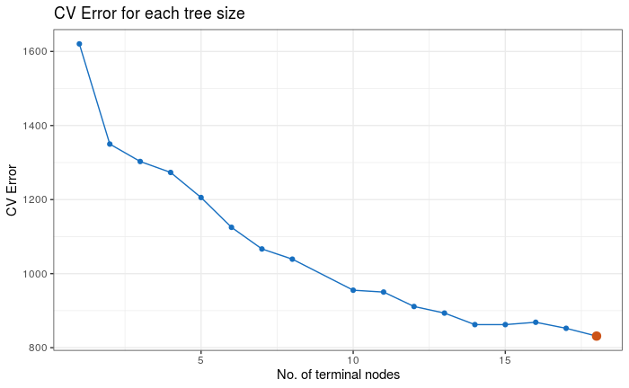

```r
# Redo the tree in this format:
tree2 <- tree(Sales ~ ., data = Carseats, subset = train)
cv.tree2 <- cv.tree(tree2)
size.min.1 <- cv.tree2$size[which.min(cv.tree2$dev)]
data.frame(size = cv.tree2$size, error = cv.tree2$dev) %>%
  ggplot(aes(size, error)) +
  geom_line(color = ISLR_blue) +
  geom_point(color = ISLR_blue) +
  geom_point(data = data.frame(x = size.min.1, y = min(cv.tree2$dev)),
             aes(x, y), color = ISLR_orange, size = 3) +
  labs(x = "No. of terminal nodes", y = "CV Error",
       title = "CV Error for each tree size")
```

Cross validation selects the most complex tree (size = 18), for which we already calculated the test MSE (4.92).

Plot the test MSE for pruned trees:

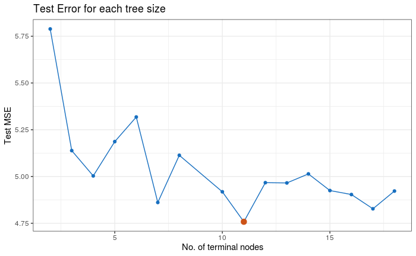

```r
sizes <- rev(cv.tree2$size)[-1]
tree2.pruned <- map(sizes, function(t) prune.tree(tree2, best = t))  # exclude single node tree
MSE.pruned <- map_dbl(tree2.pruned, function(t) mean((predict(t, newdata = df[test, ]) - y[test])^2))
names(MSE.pruned) <- str_c("size = ", sizes)
size.min.2 <- sizes[which.min(MSE.pruned)]

data.frame(size = sizes, MSE = MSE.pruned) %>%
  ggplot(aes(size, MSE)) +
  geom_line(color = ISLR_blue) +
  geom_point(color = ISLR_blue) +
  geom_point(data = data.frame(x = size.min.2, y = min(MSE.pruned)),
             aes(x, y), color = ISLR_orange, size = 3) +
  labs(x = "No. of terminal nodes", y = "Test MSE",
       title = "Test Error for each tree size")
```

When the pruned trees are used to calculate test MSE, we see that a tree of size 11 actually produces the lowest error.

```r
MSE <- c(MSE, "Pruned Regression Tree" = MSE.pruned[which.min(MSE.pruned)])
MSE[2]
```

```
Pruned Regression Tree.size = 11
                        4.757881
```

### (d)

Use the bagging approach in order to analyze this data:

```r
set.seed(1)
bag.1 <- randomForest(y ~ ., data = df[train, ], mtry = p, importance = TRUE)
bag.1
```

```
Call:
 randomForest(formula = y ~ ., data = df[train, ], mtry = p, importance = TRUE)
               Type of random forest: regression
                     Number of trees: 500
No. of variables tried at each split: 10

          Mean of squared residuals: 2.889221
                    % Var explained: 63.26
```

Test MSE:

```r
yhat.bag <- predict(bag.1, newdata = df[test, ])
MSE.bag <- mean((yhat.bag - y[test])^2)
MSE <- c(MSE, "Bagging" = MSE.bag)
MSE[3]
```

```
 Bagging
2.605253
```

Variable importance:

```r
importance(bag.1)
```

```
               %IncMSE IncNodePurity
CompPrice   24.8888481    170.182937
Income       4.7121131     91.264880
Advertising 12.7692401     97.164338
Population  -1.8074075     58.244596
Price       56.3326252    502.903407
ShelveLoc   48.8886689    380.032715
Age         17.7275460    157.846774
Education    0.5962186     44.598731
Urban        0.1728373      9.822082
US           4.2172102     18.073863
```

Plot:

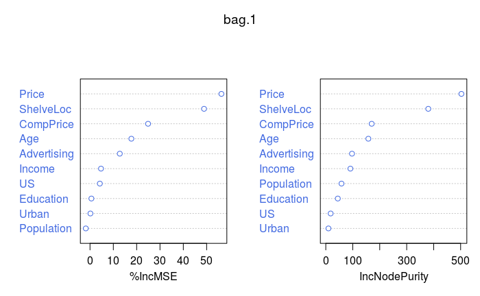

```r
varImpPlot(bag.1, col = "royalblue")
```

### (e)

Use random forests to analyze this data:

```r
set.seed(1)

M <- c(2:9)
rfs <- map(M, function(m) randomForest(y ~ ., data = df[train, ], mtry = m, importance = TRUE))
yhat.rf <- map(rfs, function(rf) predict(rf, newdata = df[test, ]))
MSE.rfs <- map_dbl(yhat.rf, function(yhat) mean((yhat - y[test])^2))
names(MSE.rfs) <- str_c("m = ", M)
MSE.rfs
```

```
   m = 2    m = 3    m = 4    m = 5    m = 6    m = 7    m = 8    m = 9
3.401523 3.019287 2.821882 2.714157 2.638459 2.619630 2.683607 2.577058
```

```r
MSE.rfs[which.min(MSE.rfs)]
```

```
   m = 9
2.577058
```

```r
m.min <- M[which.min(MSE.rfs)]
MSE <- c(MSE, "Random Forest" = MSE.rfs[which.min(MSE.rfs)])
```

Plot the test error for each value of `mtry`:

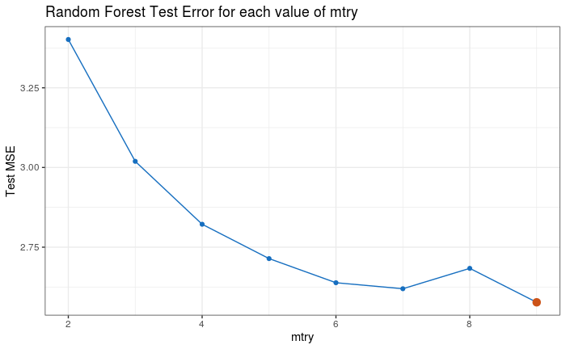

```r
data.frame(mtry = M, MSE = MSE.rfs) %>%
  ggplot(aes(mtry, MSE)) +
  geom_line(color = ISLR_blue) +
  geom_point(color = ISLR_blue) +
  geom_point(data = data.frame(x = m.min, y = min(MSE.rfs)),
             aes(x, y), color = ISLR_orange, size = 3) +
  labs(x = "mtry", y = "Test MSE",
       title = "Random Forest Test Error for each value of mtry")
```

Random forests achieved a minimum test MSE with $m$ of 9.

Generate a random forest on all of the data with $m$ = 9:

```r
rf <- randomForest(y ~ ., data = df, mtry = m.min, importance = TRUE)
```

Variable importance:

```r
importance(rf)
```

```
              %IncMSE IncNodePurity
CompPrice   39.278218     325.92575
Income      13.702897     168.01384
Advertising 26.985973     227.15398
Population   1.676892     101.49181
Price       81.070954     902.66392
ShelveLoc   86.598547     980.32185
Age         26.506530     286.49019
Education    2.606558      82.47462
Urban       -1.834016      13.71284
US           4.504569      17.85892
```

Plot:

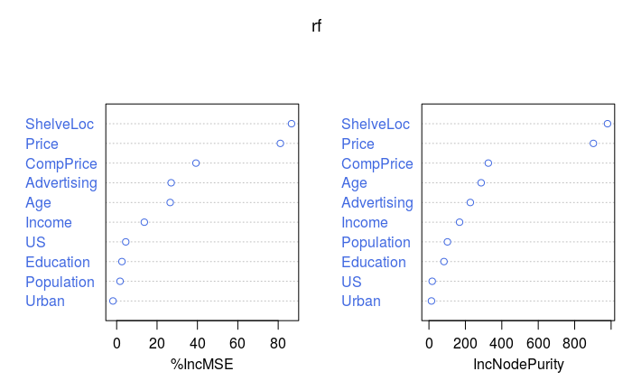

```r
varImpPlot(rf, col = "royalblue")
```

Test errors for all methods:

```r
sort(round(MSE, 2))
```

```
             Random Forest.m = 9                          Bagging Pruned Regression Tree.size = 11
                            2.58                             2.61                             4.76
                 Regression Tree
                            4.92
```

## Exercise 9

View data:

```r
OJ
```

|  | Purchase | WeekofPurchase | StoreID | PriceCH | PriceMM | DiscCH | DiscMM | SpecialCH | SpecialMM | LoyalCH | SalePriceMM | SalePriceCH | PriceDiff | Store7 | PctDiscMM | PctDiscCH | ListPriceDiff | STORE |
| --- | --- | --- | --- | --- | --- | --- | --- | --- | --- | --- | --- | --- | --- | --- | --- | --- | --- | --- |
| 1 | CH | 237 | 1 | 1.75 | 1.99 | 0.00 | 0.00 | 0 | 0 | 0.500000 | 1.99 | 1.75 | 0.24 | No | 0.000000 | 0.000000 | 0.24 | 1 |
| 2 | CH | 239 | 1 | 1.75 | 1.99 | 0.00 | 0.30 | 0 | 1 | 0.600000 | 1.69 | 1.75 | -0.06 | No | 0.150754 | 0.000000 | 0.24 | 1 |
| 3 | CH | 245 | 1 | 1.86 | 2.09 | 0.17 | 0.00 | 0 | 0 | 0.680000 | 2.09 | 1.69 | 0.40 | No | 0.000000 | 0.091398 | 0.23 | 1 |
| 4 | MM | 227 | 1 | 1.69 | 1.69 | 0.00 | 0.00 | 0 | 0 | 0.400000 | 1.69 | 1.69 | 0.00 | No | 0.000000 | 0.000000 | 0.00 | 1 |
| 5 | CH | 228 | 7 | 1.69 | 1.69 | 0.00 | 0.00 | 0 | 0 | 0.956535 | 1.69 | 1.69 | 0.00 | Yes | 0.000000 | 0.000000 | 0.00 | 0 |
| 6 | CH | 230 | 7 | 1.69 | 1.99 | 0.00 | 0.00 | 0 | 1 | 0.965228 | 1.99 | 1.69 | 0.30 | Yes | 0.000000 | 0.000000 | 0.30 | 0 |
| 7 | CH | 232 | 7 | 1.69 | 1.99 | 0.00 | 0.40 | 1 | 1 | 0.972182 | 1.59 | 1.69 | -0.10 | Yes | 0.201005 | 0.000000 | 0.30 | 0 |
| 8 | CH | 234 | 7 | 1.75 | 1.99 | 0.00 | 0.40 | 1 | 0 | 0.977746 | 1.59 | 1.75 | -0.16 | Yes | 0.201005 | 0.000000 | 0.24 | 0 |
| 9 | CH | 235 | 7 | 1.75 | 1.99 | 0.00 | 0.40 | 0 | 0 | 0.982197 | 1.59 | 1.75 | -0.16 | Yes | 0.201005 | 0.000000 | 0.24 | 0 |
| 10 | CH | 238 | 7 | 1.75 | 1.99 | 0.00 | 0.40 | 0 | 0 | 0.985757 | 1.59 | 1.75 | -0.16 | Yes | 0.201005 | 0.000000 | 0.24 | 0 |

[output cut: 990 more lines]

### (a)

Create a training set containing a random sample of 800 observations, and a test set containing the remaining observations:

```r
### Data:
print(str_c(1:ncol(OJ), ": ", names(OJ)))
```

```
 [1] "1: Purchase"       "2: WeekofPurchase" "3: StoreID"        "4: PriceCH"        "5: PriceMM"        "6: DiscCH"
 [7] "7: DiscMM"         "8: SpecialCH"      "9: SpecialMM"      "10: LoyalCH"       "11: SalePriceMM"   "12: SalePriceCH"
[13] "13: PriceDiff"     "14: Store7"        "15: PctDiscMM"     "16: PctDiscCH"     "17: ListPriceDiff" "18: STORE"
```

```r
### Train/Test:
set.seed(1)
train <- sample(nrow(OJ), 800)
test <- (-train)
```

### (b)

Fit a tree to the training data, with `Purchase` as the response and the other variables as predictors:

```r
tree.3 <- tree(Purchase ~ ., data = OJ[train, ])
tree.3.sum <- summary(tree.3)
tree.3.sum
```

```
Classification tree:
tree(formula = Purchase ~ ., data = OJ[train, ])
Variables actually used in tree construction:
[1] "LoyalCH"       "PriceDiff"     "SpecialCH"     "ListPriceDiff" "PctDiscMM"
Number of terminal nodes:  9
Residual mean deviance:  0.7432 = 587.8 / 791
Misclassification error rate: 0.1588 = 127 / 800
```

The variables used in constructing the tree:

```r
tree.3.sum$used
```

```
[1] LoyalCH       PriceDiff     SpecialCH     ListPriceDiff PctDiscMM
18 Levels: <leaf> WeekofPurchase StoreID PriceCH PriceMM DiscCH DiscMM SpecialCH SpecialMM LoyalCH SalePriceMM ... STORE
```

Number of terminal nodes:

```r
tree.3.sum$size
```

```
[1] 9
```

Training error rate:

```r
tree.3.error.train <- tree.3.sum$misclass[1] / tree.3.sum$misclass[2]
tree.3.error.train
```

```
[1] 0.15875
```

### (c)

Print tree output:

```r
tree.3.sum
```

```
Classification tree:
tree(formula = Purchase ~ ., data = OJ[train, ])
Variables actually used in tree construction:
[1] "LoyalCH"       "PriceDiff"     "SpecialCH"     "ListPriceDiff" "PctDiscMM"
Number of terminal nodes:  9
Residual mean deviance:  0.7432 = 587.8 / 791
Misclassification error rate: 0.1588 = 127 / 800
```

### (d)

Plot tree:

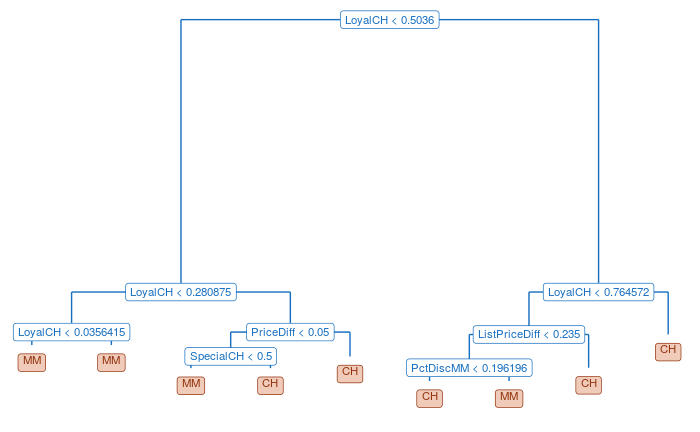

```r
# Use ggdendro to extract the tree data:
# Ref: http://andrie.github.io/ggdendro/
tree3_data <- dendro_data(tree.3)

# The above functions doesn't fully extract the splits, so I need to do this separately:
# (This code isn't perfect, especially with factors)
# Full data frame of tree data:
tree3_nodes <- data.frame(
  var = tree.3$frame$var,
  n = tree.3$frame$n,
  dev = tree.3$frame$dev,
  yval = tree.3$frame$yval,
  splits = tree.3$frame$splits
) %>%
  mutate(`cutleft (<)` = str_replace(splits.cutleft, "<", ""),
         `cutright (>)` = str_replace(splits.cutright, ">", "")) %>%
  dplyr::select(-splits.cutleft, -splits.cutright)
# Extract the labels:
labels <- tree3_nodes %>%
  filter(var != "<leaf>") %>%
  mutate(label = ifelse(!str_detect(`cutleft (<)`, "[A-Za-z]"),
                         str_c(var, " < ", `cutleft (<)`),
                         str_c(var, "", `cutleft (<)`)))%>%
  select(label)

# Replace the labels with the new ones that include the splits:
tree3_data$labels$label <- labels[[1]]

# Plot:
ggplot() +
  geom_segment(data = segment(tree3_data),
               aes(x = x, y = y, xend = xend, yend = yend),
               color = ISLR_blue
  ) +
  geom_label(data = label(tree3_data),
            aes(x = x, y = y, label = label, hjust = 0.5, vjust = ),
            size = 3, fill = "white", color = ISLR_blue, alpha = 1
  ) +
  geom_label(data = leaf_label(tree3_data),
            aes(x = x, y = y, label = label, hjust = 0.5, vjust = 1.5),
            size = 3, fill = ISLR_orange, color = ISLR_brown, alpha = 0.3
  ) +
  coord_cartesian(ylim = c(650, NA)) + # could automate this
  theme_void() +
  theme(plot.title = element_text(hjust = 0.5))
```

### (e)

Make predictions on test data:

```r
preds <- predict(tree.3, newdata = OJ[test, ], type = "class")
tab <- table(preds, OJ$Purchase[test])
tab
```

```
preds  CH  MM
   CH 160  38
   MM   8  64
```

Test error (misclassifications):

```r
tree.3.error.test <- (tab[1, 2] + tab[2, 1]) / sum(tab)
tree.3.error.test
```

```
[1] 0.1703704
```

The test error (0.17) is slightly worse than the training error (0.159).

Use `caret::confusionMatrix()` to get a more comprehensive set of metrics:

```r
caret::confusionMatrix(preds, OJ$Purchase[test])
```

```
Confusion Matrix and Statistics

          Reference
Prediction  CH  MM
        CH 160  38
        MM   8  64

               Accuracy : 0.8296
                 95% CI : (0.7794, 0.8725)
    No Information Rate : 0.6222
    P-Value [Acc > NIR] : 8.077e-14

                  Kappa : 0.6154

 Mcnemar's Test P-Value : 1.904e-05

            Sensitivity : 0.9524
            Specificity : 0.6275
         Pos Pred Value : 0.8081
         Neg Pred Value : 0.8889
             Prevalence : 0.6222
         Detection Rate : 0.5926
   Detection Prevalence : 0.7333
      Balanced Accuracy : 0.7899

       'Positive' Class : CH
```

### (f)

Apply the `cv.tree()` function to the training set in order to determine the optimal tree size:

```r
cv.tree.3 <- cv.tree(tree.3, FUN = prune.misclass)
tree.3.cv.error <- cv.tree.3$dev[which.min(cv.tree.3$dev)]
tree.3.cv.size <- cv.tree.3$size[which.min(cv.tree.3$dev)]
cv.tree.3
```

```
$size
[1] 9 8 7 4 2 1

$dev
[1] 150 150 149 158 172 315

$k
[1]       -Inf   0.000000   3.000000   4.333333  10.500000 151.000000

$method
[1] "misclass"

attr(,"class")
[1] "prune"         "tree.sequence"
```

### (g)

Plot errors:

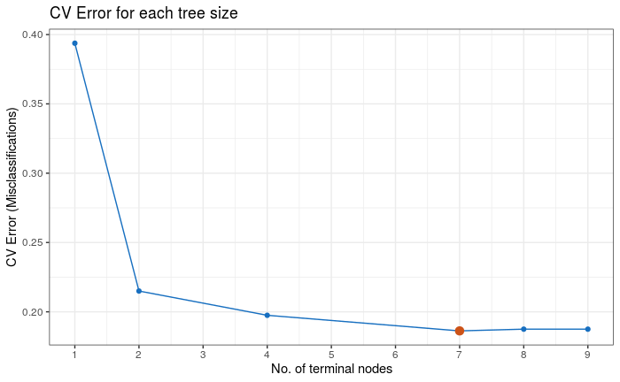

```r
data.frame(size = cv.tree.3$size, error = cv.tree.3$dev/800) %>%
  ggplot(aes(size, error)) +
  geom_line(color = ISLR_blue) +
  geom_point(color = ISLR_blue) +
  geom_point(data = data.frame(x = tree.3.cv.size, y = tree.3.cv.error / 800),
             aes(x, y), color = ISLR_orange, size = 3) +
  scale_x_continuous(breaks = 1:max(cv.tree.3$size)) +
  labs(x = "No. of terminal nodes", y = "CV Error (Misclassifications)",
       title = "CV Error for each tree size")
```

### (h)

The tree with size = 7 produces the lowest CV error (0.186).

### (i)

Produce a pruned tree corresponding to the optimal tree size obtained using cross-validation:

```r
tree.3.prune <- prune.misclass(tree.3, best = tree.3.cv.size)
tree.3.prune.sum <- summary(tree.3.prune)
tree.3.prune.sum
```

```
Classification tree:
snip.tree(tree = tree.3, nodes = c(4L, 10L))
Variables actually used in tree construction:
[1] "LoyalCH"       "PriceDiff"     "ListPriceDiff" "PctDiscMM"
Number of terminal nodes:  7
Residual mean deviance:  0.7748 = 614.4 / 793
Misclassification error rate: 0.1625 = 130 / 800
```

### (j)

```r
tree.3.prune.error.train <- tree.3.prune.sum$misclass[1] / tree.3.prune.sum$misclass[2]
tree.3.prune.error.train
```

```
[1] 0.1625
```

The training error of the pruned tree (0.162) is slightly higher than the unpruned tree (0.159).

### (k)

```r
preds.prune <- predict(tree.3.prune, newdata = OJ[test, ], type = "class")
tab.prune <- table(preds, OJ$Purchase[test])
tab.prune
```

```
preds  CH  MM
   CH 160  38
   MM   8  64
```

Test error (misclassifications):

```r
tree.3.prune.error.test <- (tab.prune[1, 2] + tab.prune[2, 1]) / sum(tab.prune)
tree.3.prune.error.test
```

```
[1] 0.1703704
```

## Exercise 10

View data:

```r
Hitters
```

|  | AtBat | Hits | HmRun | Runs | RBI | Walks | Years | CAtBat | CHits | CHmRun | CRuns | CRBI | CWalks | League | Division | PutOuts | Assists | Errors | Salary | NewLeague |
| --- | --- | --- | --- | --- | --- | --- | --- | --- | --- | --- | --- | --- | --- | --- | --- | --- | --- | --- | --- | --- |
| -Andy Allanson | 293 | 66 | 1 | 30 | 29 | 14 | 1 | 293 | 66 | 1 | 30 | 29 | 14 | A | E | 446 | 33 | 20 | NA | A |
| -Alan Ashby | 315 | 81 | 7 | 24 | 38 | 39 | 14 | 3449 | 835 | 69 | 321 | 414 | 375 | N | W | 632 | 43 | 10 | 475.000 | N |
| -Alvin Davis | 479 | 130 | 18 | 66 | 72 | 76 | 3 | 1624 | 457 | 63 | 224 | 266 | 263 | A | W | 880 | 82 | 14 | 480.000 | A |
| -Andre Dawson | 496 | 141 | 20 | 65 | 78 | 37 | 11 | 5628 | 1575 | 225 | 828 | 838 | 354 | N | E | 200 | 11 | 3 | 500.000 | N |
| -Andres Galarraga | 321 | 87 | 10 | 39 | 42 | 30 | 2 | 396 | 101 | 12 | 48 | 46 | 33 | N | E | 805 | 40 | 4 | 91.500 | N |
| -Alfredo Griffin | 594 | 169 | 4 | 74 | 51 | 35 | 11 | 4408 | 1133 | 19 | 501 | 336 | 194 | A | W | 282 | 421 | 25 | 750.000 | A |
| -Al Newman | 185 | 37 | 1 | 23 | 8 | 21 | 2 | 214 | 42 | 1 | 30 | 9 | 24 | N | E | 76 | 127 | 7 | 70.000 | A |
| -Argenis Salazar | 298 | 73 | 0 | 24 | 24 | 7 | 3 | 509 | 108 | 0 | 41 | 37 | 12 | A | W | 121 | 283 | 9 | 100.000 | A |
| -Andres Thomas | 323 | 81 | 6 | 26 | 32 | 8 | 2 | 341 | 86 | 6 | 32 | 34 | 8 | N | W | 143 | 290 | 19 | 75.000 | N |
| -Andre Thornton | 401 | 92 | 17 | 49 | 66 | 65 | 13 | 5206 | 1332 | 253 | 784 | 890 | 866 | A | E | 0 | 0 | 0 | 1100.000 | A |

[output cut: 312 more lines]

### (a)

Remove the observations for whom the salary information is unknown, and then log-transform the salaries:

```r
### Data
data <- Hitters %>%
  filter(!is.na(Salary)) %>%
  mutate(Salary.log = log(Salary)) # `data` is the full data set
str_c(1:ncol(data), ": ", names(data))
```

```
 [1] "1: AtBat"       "2: Hits"        "3: HmRun"       "4: Runs"        "5: RBI"         "6: Walks"       "7: Years"
 [8] "8: CAtBat"      "9: CHits"       "10: CHmRun"     "11: CRuns"      "12: CRBI"       "13: CWalks"     "14: League"
[15] "15: Division"   "16: PutOuts"    "17: Assists"    "18: Errors"     "19: Salary"     "20: NewLeague"  "21: Salary.log"
```

### (b)

Create a training set consisting of the first 200 observations, and a test set consisting of the remaining observations:

```r
### Train/Test:
set.seed(1)
train <- 1:200
test <- (-train)

y.index <- 21 # column index of response variable
X <- data[ , -c(y.index, 19)]
y <- data[, y.index]
n <- nrow(X)
p <- ncol(X)
var.names <- names(X)
df <- data.frame(X, y) # data.frame for use in modeling

# Best Subset
r.max = p # `nvmax` in regsubsets()

# Ridge/Lasso
X.mod <- model.matrix(y ~ ., X)[, -1]
grid <- 10^seq(10, -2, length=100) # lambda values

### CV
k = 10
folds <- sample(1:k, nrow(X[train, ]), replace=TRUE)
cv.errors <- matrix(NA, k, r.max, dimnames=list(NULL, paste(1:r.max)))
predict.regsubsets <- function(object, newdata, id,...) {
  form <- as.formula(object$call[[2]])
  mat <- model.matrix(form, newdata)
  coefi <- coef(object, id=id)
  xvars <- names(coefi)
  mat[, xvars]%*%coefi
}

# Error:
MSE_10 <- c()
```

### (c)

Perform boosting on the training set with 1,000 trees for a range of values of the shrinkage parameter $\lambda$. Produce a plot with different shrinkage values on the x-axis and the corresponding training set MSE on the y-axis:

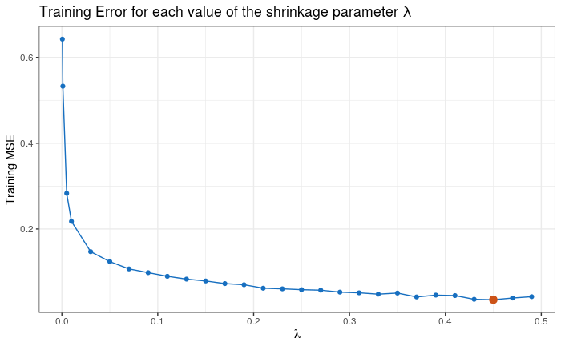

```r
lambdas <- c(0.0005, 0.001, 0.005, seq(0.01, 0.5, by = 0.02))
boost.list <- map(lambdas, function(lambda) gbm(y ~ ., data = df[train, ], distribution = "gaussian", n.trees = 1000, shrinkage = lambda))
boost.error.train <- map_dbl(boost.list, function(boost) mean(boost$train.error))

data.frame(lambda  = lambdas, error = boost.error.train) %>%
  ggplot(aes(lambda, error)) +
  geom_line(color = ISLR_blue) +
  geom_point(color = ISLR_blue) +
  geom_point(data = data.frame(x = lambdas[which.min(boost.error.train)], y = min(boost.error.train)),
             aes(x, y), color = ISLR_orange, size = 3) +
  labs(x = expression(lambda), y = "Training MSE",
       title = "Training Error for each value of the shrinkage parameter λ")
```

### (d)

Produce a plot with different shrinkage values on the x-axis and the corresponding test set MSE on the y-axis:

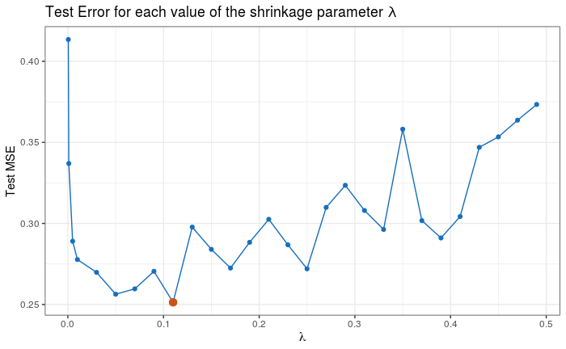

```r
yhat.boost <- map(boost.list, function(boost) predict(boost, newdata = df[test, ], n.trees = 1000))

boost.error.test <- map_dbl(yhat.boost, function(yhat) mean((yhat - y[test])^2))
boost.error.test.min <-  min(boost.error.test)
MSE_10 = c(MSE_10, boosting = boost.error.test.min)

data.frame(lambda  = lambdas, error = boost.error.test) %>%
  ggplot(aes(lambda, error)) +
  geom_line(color = ISLR_blue) +
  geom_point(color = ISLR_blue) +
  geom_point(data = data.frame(x = lambdas[which.min(boost.error.test)], y = min(boost.error.test)),
             aes(x, y), color = ISLR_orange, size = 3) +
  labs(x = expression(lambda), y = "Test MSE",
       title = "Test Error for each value of the shrinkage parameter λ")
```

### (e)

Compare the test MSE of boosting to the test MSE that results from applying two of the regression approaches seen in Chapters 3 and 6.

#### Best Subset Selection

Use best subset selection and cross-validation (on the training set only) to select a model:

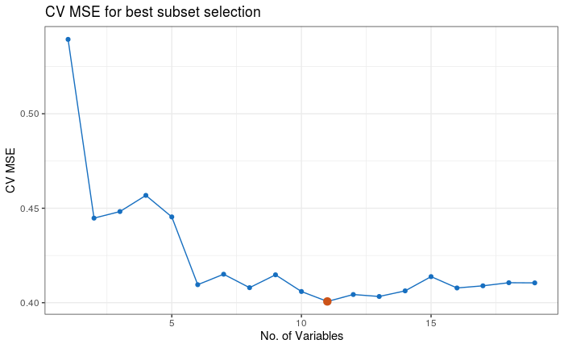

```r
for(j in 1:k) {
  best.fit <- regsubsets(y ~ ., data=df[train, ][folds!=j, ], nvmax=r.max)
  for(i in 1:r.max) {
    pred <- predict.regsubsets(best.fit, df[train, ][folds==j, ], id=i)
    cv.errors[j, i] = mean((pred - y[train][folds==j])^2)
  }
}
mean.cv.errors <- apply(cv.errors, 2, mean)
p.min <- which.min(mean.cv.errors)

# Plot errors
data.frame(p  = 1:r.max, error = mean.cv.errors) %>%
  ggplot(aes(p, error)) +
  geom_line(color = ISLR_blue) +
  geom_point(color = ISLR_blue) +
  geom_point(data = data.frame(x = which.min(mean.cv.errors), y = mean.cv.errors[which.min(mean.cv.errors)]),
             aes(x, y), color = ISLR_orange, size = 3) +
  labs(x = "No. of Variables", y = "CV MSE",
       title = "CV MSE for best subset selection")
```

Best subset selection on the training set with cross-validation has chosen the 11-variable model as the model with lowest CV error.

To calculate the test error, we use best subset selection on the training set, then make predictions on the test set using the 11-variable model:

```r
#p.alt = 3 # Uncomment this to use an alternative no. of variables. Comment lines marked #p.min#. Uncomment lines marked #alt.p#
reg.best <- regsubsets(y ~ ., data=df[train, ], nvmax=r.max)
reg.best.pred <- predict(reg.best, df[test, ], id=p.min) #p.min#
#reg.best.pred <- predict(reg.best, df[test, ], id=p.alt) #p.alt#
reg.best.test.error <- mean((reg.best.pred - y[test])^2)
MSE_10 = c(MSE_10, reg.best = reg.best.test.error)
reg.best.test.error
```

```
[1] 0.4896387
```

For the final model, perform best subset selection on the whole data set and obtain coefficients for the 11-variable model:

```r
reg.best <- regsubsets(y ~ ., data=df, nvmax=p)
reg.best.omit <- names(coef(reg.best, p.min)[-1]) #p.min#
#reg.best.omit <- names(coef(reg.best, p.alt)[-1]) #p.alt#
round(coef(reg.best, p.min), 3) #p.min#
```

```
(Intercept)       AtBat        Hits       HmRun       Walks       Years       CRuns      CWalks     LeagueN   DivisionW
      4.545      -0.003       0.012       0.006       0.010       0.065       0.001      -0.001       0.277      -0.161
    PutOuts  NewLeagueN
      0.000      -0.174
```

```r
#round(coef(reg.best, p.alt), 3) #p.alt#
```

The variables omitted by best subset selection are:

```r
var.names[!var.names %in% names(coef(reg.best, p.min)[-1])] #p.min#
```

```
 [1] "Runs"      "RBI"       "CAtBat"    "CHits"     "CHmRun"    "CRBI"      "League"    "Division"  "Assists"   "Errors"
[11] "NewLeague"
```

```r
#var.names[!var.names %in% names(coef(reg.best, p.alt)[-1])] #p.alt#
```

#### Ridge Regression

Use cross-validation to choose an optimal $\lambda$ for ridge regression:

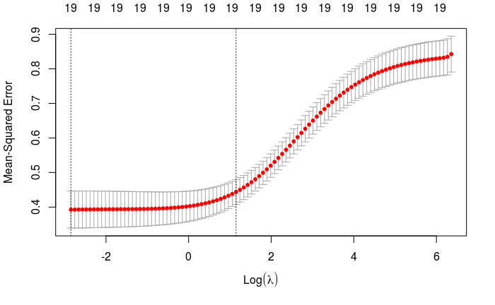

```r
set.seed(1)
cv.out <- cv.glmnet(X.mod[train, ], y[train], alpha=0)
best.lam <- cv.out$lambda.min

plot(cv.out)
```

Calculate the test error of ridge regression using the optimal $\lambda$ found by cross-validation:

```r
ridge.train <- glmnet(X.mod[train, ], y[train], alpha=0, lambda=best.lam)
ridge.pred <- predict(ridge.train, alpha=0, newx=X.mod[test, ])
ridge.test.error <- mean((ridge.pred - y[test])^2)
MSE_10 = c(MSE_10, ridge = ridge.test.error)
ridge.test.error
```

```
[1] 0.4568975
```

Generate a ridge regression on all of the data, then report the coefficients of the best model as obtained by cross-validation:

```r
ridge <- glmnet(X.mod, y, alpha=0, lambda=best.lam)
ridge.coef <- predict(ridge, type="coefficients")[1:p+1, ]
round(ridge.coef, 3)
```

```
     AtBat       Hits      HmRun       Runs        RBI      Walks      Years     CAtBat      CHits     CHmRun      CRuns
    -0.001      0.004      0.003      0.003      0.001      0.005      0.042      0.000      0.000      0.000      0.000
      CRBI     CWalks    LeagueN  DivisionW    PutOuts    Assists     Errors NewLeagueN
     0.000      0.000      0.208     -0.167      0.000      0.000     -0.012     -0.109
```

Ridge regression does not perform feature selection, but the variables with small coefficients are:

```r
names(which(abs(ridge.coef) < 0.01))
```

```
 [1] "AtBat"   "Hits"    "HmRun"   "Runs"    "RBI"     "Walks"   "CAtBat"  "CHits"   "CHmRun"  "CRuns"   "CRBI"    "CWalks"
[13] "PutOuts" "Assists"
```

#### Lasso

Use cross-validation to choose an optimal $\lambda$ for the lasso:

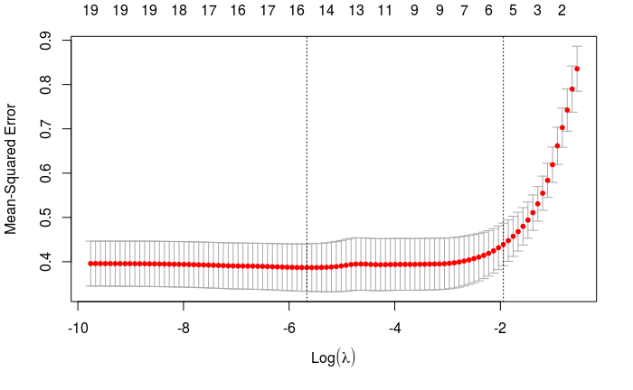

```r
set.seed(1)
lasso.cv <- cv.glmnet(X.mod[train, ], y[train], alpha=1)
best.lam <- lasso.cv$lambda.min

plot(lasso.cv)
```

Calculate the test error of the lasso using the optimal $\lambda$ found by cross-validation:

```r
lasso.train <- glmnet(X.mod[train, ], y[train], alpha=1, lambda=best.lam)
lasso.pred <- predict(lasso.train, alpha=1, newx=X.mod[test, ])
lasso.test.error = mean((lasso.pred - y[test])^2)
MSE_10 = c(MSE_10, lasso=lasso.test.error)
lasso.test.error
```

```
[1] 0.4709523
```

Generate a lasso model on all of the data, then report the coefficients of the best model as obtained by cross-validation:

```r
lasso <- glmnet(X.mod, y, alpha=1, lambda=best.lam)
lasso.coef <- predict(lasso, type="coefficients")[1:p+1, ]
round(lasso.coef, 3)
```

```
     AtBat       Hits      HmRun       Runs        RBI      Walks      Years     CAtBat      CHits     CHmRun      CRuns
    -0.002      0.009      0.007      0.000      0.000      0.008      0.057      0.000      0.000      0.000      0.001
      CRBI     CWalks    LeagueN  DivisionW    PutOuts    Assists     Errors NewLeagueN
     0.000     -0.001      0.236     -0.162      0.000      0.000     -0.011     -0.132
```

The variables omitted by the lasso are:

```r
var.names[!var.names %in% names(lasso.coef[which(lasso.coef!=0)])]
```

```
[1] "RBI"       "CAtBat"    "CRBI"      "League"    "Division"  "NewLeague"
```

#### PCR

Fit a principal components regression model on the data:

```r
set.seed(1)
pcr.fit <- pcr(y ~ ., data=df, subset=train, scale=TRUE, validation="CV")
summary(pcr.fit)
```

```
Data:   X dimension: 200 19
    Y dimension: 200 1
Fit method: svdpc
Number of components considered: 19

VALIDATION: RMSEP
Cross-validated using 10 random segments.
       (Intercept)  1 comps  2 comps  3 comps  4 comps  5 comps  6 comps  7 comps  8 comps  9 comps  10 comps  11 comps
CV          0.9167   0.6462   0.6493   0.6515   0.6534   0.6507   0.6487   0.6502   0.6466   0.6473    0.6489    0.6510
adjCV       0.9167   0.6453   0.6481   0.6501   0.6517   0.6485   0.6466   0.6480   0.6442   0.6448    0.6463    0.6489
       12 comps  13 comps  14 comps  15 comps  16 comps  17 comps  18 comps  19 comps
CV       0.6509    0.6457    0.6471    0.6515    0.6415    0.6435    0.6479    0.6481
adjCV    0.6481    0.6428    0.6439    0.6481    0.6380    0.6394    0.6437    0.6437

TRAINING: % variance explained
   1 comps  2 comps  3 comps  4 comps  5 comps  6 comps  7 comps  8 comps  9 comps  10 comps  11 comps  12 comps  13 comps
X    39.40    60.67    70.76    79.64    84.73    89.29    92.38    95.02    96.32     97.26     98.06     98.72     99.23
y    52.42    52.67    53.22    53.56    54.56    55.34    55.70    56.48    56.68     56.77     56.80     57.41     57.91
   14 comps  15 comps  16 comps  17 comps  18 comps  19 comps
X     99.54     99.77     99.90     99.97     99.99    100.00
y     58.68     58.75     60.27     61.27     61.27     61.49
```

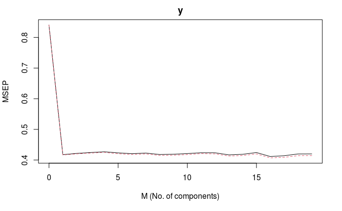

```r
validationplot(pcr.fit, val.type="MSEP", xlab="M (No. of components)")
```

Choose $M$:

```r
M = 1
```

Calculate the test error for a 1-component PCR model:

```r
pcr.pred <- predict(pcr.fit, df[test, ], ncomp=M)
pcr.test.error <- mean((pcr.pred - y[test])^2)
MSE_10 = c(MSE_10, pcr = pcr.test.error)
pcr.test.error
```

```
[1] 0.4661183
```

#### PLS

Fit a partial least squares model on the data:

```r
set.seed(1)
pls.fit <- plsr(y ~ ., data=df, subset=train, scale=TRUE, validation="CV")
summary(pls.fit)
```

```
Data:   X dimension: 200 19
    Y dimension: 200 1
Fit method: kernelpls
Number of components considered: 19

VALIDATION: RMSEP
Cross-validated using 10 random segments.
       (Intercept)  1 comps  2 comps  3 comps  4 comps  5 comps  6 comps  7 comps  8 comps  9 comps  10 comps  11 comps
CV          0.9167   0.6449   0.6528   0.6456   0.6448   0.6440   0.6425   0.6454   0.6450   0.6427    0.6448    0.6450
adjCV       0.9167   0.6438   0.6498   0.6434   0.6424   0.6412   0.6398   0.6420   0.6415   0.6393    0.6411    0.6411
       12 comps  13 comps  14 comps  15 comps  16 comps  17 comps  18 comps  19 comps
CV       0.6460    0.6452    0.6456    0.6460    0.6486    0.6510    0.6506    0.6481
adjCV    0.6418    0.6412    0.6415    0.6419    0.6443    0.6464    0.6459    0.6437

TRAINING: % variance explained
   1 comps  2 comps  3 comps  4 comps  5 comps  6 comps  7 comps  8 comps  9 comps  10 comps  11 comps  12 comps  13 comps
X    39.33    49.63    65.18    73.74    77.53    83.43    87.87    90.81    93.32     95.38     96.98     97.57     98.22
y    53.65    56.20    57.05    57.75    58.77    59.39    59.92    60.30    60.67     60.92     61.10     61.23     61.28
   14 comps  15 comps  16 comps  17 comps  18 comps  19 comps
X     98.67     99.01     99.70     99.89     99.97    100.00
y     61.32     61.35     61.36     61.41     61.49     61.49
```

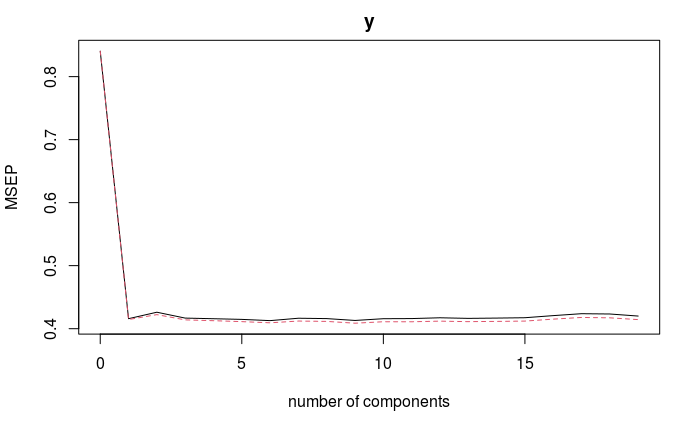

```r
validationplot(pls.fit, val.type="MSEP")
```

Choose $M$:

```r
M = 1
```

Calculate the test error for a 1-component PLS model:

```r
pls.pred <- predict(pls.fit, df[test, ], ncomp=M)
pls.test.error <- mean((pls.pred - y[test])^2)
MSE_10 = c(MSE_10, pls = pls.test.error)
pls.test.error
```

```
[1] 0.4659979
```

#### Test Errors

Inspect the test errors of the models:

```r
sort(MSE_10)
```

```
 boosting     ridge       pls       pcr     lasso  reg.best
0.2513666 0.4568975 0.4659979 0.4661183 0.4709523 0.4896387
```

Calculate the test $R^2$ values:

```r
# For RSS, R^2 can be calculated using 1 - sum((y[test] - ridge.pred)^2)/sum((y[test] - test.avg)^2). For MSE the below is used:
test.avg <- mean(y[test])
boost.test.r2 <- 1 - boost.error.test.min / mean((test.avg - y[test])^2)
reg.best.test.r2 <- 1 - reg.best.test.error / mean((test.avg - y[test])^2)
ridge.test.r2 <- 1 - ridge.test.error / mean((test.avg - y[test])^2)
lasso.test.r2 <- 1 - lasso.test.error / mean((test.avg - y[test])^2)
pcr.test.r2 <- 1 - pcr.test.error / mean((test.avg - y[test])^2)
pls.test.r2 <- 1 - pls.test.error / mean((test.avg - y[test])^2)
test.r2 <- c(boosting = boost.test.r2,
             reg.best = reg.best.test.r2,
             ridge = ridge.test.r2,
             lasso = lasso.test.r2,
             pcr = pcr.test.r2,
             pls = pls.test.r2)
sort(test.r2, decreasing = TRUE)
```

```
 boosting     ridge       pls       pcr     lasso  reg.best
0.6100614 0.2912265 0.2771093 0.2769225 0.2694236 0.2404359
```

Boosting significantly outperforms the other regression methods.

### (f)

Which variables appear to be the most important predictors in the boosted model?

|  | var | rel.inf |
| --- | --- | --- |
| CAtBat | CAtBat | 15.1857152 |
| PutOuts | PutOuts | 9.0690343 |
| CHits | CHits | 7.9549317 |
| CRuns | CRuns | 7.8120934 |
| CWalks | CWalks | 7.1016849 |
| Walks | Walks | 6.9586533 |
| CHmRun | CHmRun | 6.0595003 |
| RBI | RBI | 5.4009055 |
| Years | Years | 5.3951433 |
| CRBI | CRBI | 5.1758973 |

[output cut: 9 more lines]

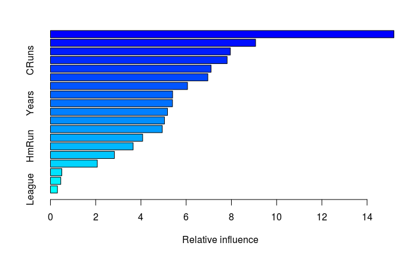

```r
boost <- boost.list[[which.min(boost.error.test)]] # Use the model with lowest test error
summary(boost)
```

The variable `CAtBat` appears to be the most important. `PutOuts`, `CHits`, `CRuns` and `CWalks` are also important. Interestingly, the variables related to the player’s **career stats** are among the most important. The variables related to the player’s **1986 stats** typically take on less importance. The non-performance-related variables (`Division`, `NewLeague` and `League`) are **all** the least important.

### (g)

Now apply bagging to the training set. What is the test set MSE for this approach?

```r
set.seed(1)
bag_10 <- randomForest(y ~ ., data = df[train, ], mtry = p, importance = TRUE)
bag_10
```

```
Call:
 randomForest(formula = y ~ ., data = df[train, ], mtry = p, importance = TRUE)
               Type of random forest: regression
                     Number of trees: 500
No. of variables tried at each split: 19

          Mean of squared residuals: 0.2178554
                    % Var explained: 73.82
```

```r
yhat.bag_10 <- predict(bag_10, newdata = df[test, ])
bag.test.error <- mean((yhat.bag_10 - y[test])^2)
MSE_10 <- c(MSE_10, "bagging" = bag.test.error)
sort(MSE_10)
```

```
  bagging  boosting     ridge       pls       pcr     lasso  reg.best
0.2301184 0.2513666 0.4568975 0.4659979 0.4661183 0.4709523 0.4896387
```

The test MSE for bagging is slightly better than that of boosting.

Variable importance:

```r
importance(bag_10)
```

```
              %IncMSE IncNodePurity
AtBat     10.36037677    7.59899089
Hits       6.69476752    4.61244229
HmRun      0.45962166    1.67420019
Runs       5.19809979    2.58312025
RBI        3.21835382    3.02919843
Walks      9.49509870    7.25161868
Years      7.94438982    1.78466935
CAtBat    34.61473697   85.80782159
CHits      7.80595151   11.13937572
CHmRun     9.87901114    4.95951018
CRuns     12.33865863   13.49631939
CRBI      11.44789911    9.52385064
CWalks     5.96869309    5.70105949
League    -0.25504777    0.09686047
Division  -2.56240113    0.15964731
PutOuts    1.72924797    2.69742165
Assists   -0.02584561    1.36241940
Errors     1.83362063    1.16664726
NewLeague  0.99642182    0.21617428
```

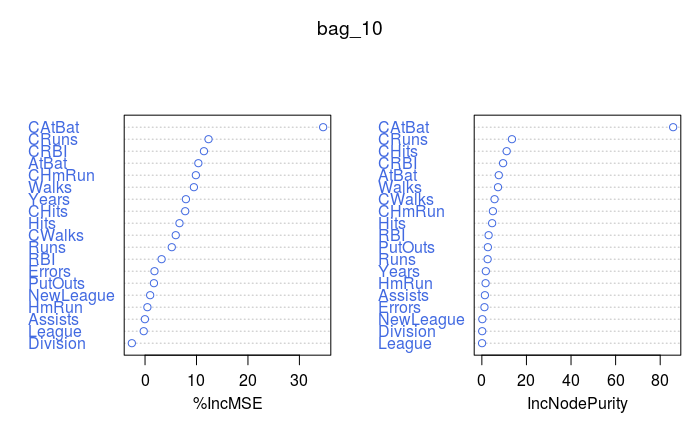

```r
varImpPlot(bag_10, col = "royalblue")
```

## Exercise 11

View data:

```r
Caravan
```

|  | MOSTYPE | MAANTHUI | MGEMOMV | MGEMLEEF | MOSHOOFD | MGODRK | MGODPR | MGODOV | MGODGE | MRELGE | MRELSA | MRELOV | MFALLEEN | MFGEKIND | MFWEKIND | MOPLHOOG | MOPLMIDD | MOPLLAAG | MBERHOOG | MBERZELF | MBERBOER | MBERMIDD | MBERARBG | MBERARBO | MSKA | MSKB1 | MSKB2 | MSKC | MSKD | … |
| --- | --- | --- | --- | --- | --- | --- | --- | --- | --- | --- | --- | --- | --- | --- | --- | --- | --- | --- | --- | --- | --- | --- | --- | --- | --- | --- | --- | --- | --- | --- |
| 1 | 33 | 1 | 3 | 2 | 8 | 0 | 5 | 1 | 3 | 7 | 0 | 2 | 1 | 2 | 6 | 1 | 2 | 7 | 1 | 0 | 1 | 2 | 5 | 2 | 1 | 1 | 2 | 6 | 1 | … |
| 2 | 37 | 1 | 2 | 2 | 8 | 1 | 4 | 1 | 4 | 6 | 2 | 2 | 0 | 4 | 5 | 0 | 5 | 4 | 0 | 0 | 0 | 5 | 0 | 4 | 0 | 2 | 3 | 5 | 0 | … |
| 3 | 37 | 1 | 2 | 2 | 8 | 0 | 4 | 2 | 4 | 3 | 2 | 4 | 4 | 4 | 2 | 0 | 5 | 4 | 0 | 0 | 0 | 7 | 0 | 2 | 0 | 5 | 0 | 4 | 0 | … |
| 4 | 9 | 1 | 3 | 3 | 3 | 2 | 3 | 2 | 4 | 5 | 2 | 2 | 2 | 3 | 4 | 3 | 4 | 2 | 4 | 0 | 0 | 3 | 1 | 2 | 3 | 2 | 1 | 4 | 0 | … |
| 5 | 40 | 1 | 4 | 2 | 10 | 1 | 4 | 1 | 4 | 7 | 1 | 2 | 2 | 4 | 4 | 5 | 4 | 0 | 0 | 5 | 4 | 0 | 0 | 0 | 9 | 0 | 0 | 0 | 0 | … |
| 6 | 23 | 1 | 2 | 1 | 5 | 0 | 5 | 0 | 5 | 0 | 6 | 3 | 3 | 5 | 2 | 0 | 5 | 4 | 2 | 0 | 0 | 4 | 2 | 2 | 2 | 2 | 2 | 4 | 2 | … |
| 7 | 39 | 2 | 3 | 2 | 9 | 2 | 2 | 0 | 5 | 7 | 2 | 0 | 0 | 3 | 6 | 0 | 4 | 5 | 0 | 0 | 0 | 4 | 1 | 5 | 0 | 1 | 4 | 5 | 0 | … |
| 8 | 33 | 1 | 2 | 3 | 8 | 0 | 7 | 0 | 2 | 7 | 2 | 0 | 0 | 5 | 4 | 0 | 3 | 6 | 2 | 0 | 0 | 2 | 5 | 2 | 2 | 1 | 2 | 5 | 2 | … |
| 9 | 33 | 1 | 2 | 4 | 8 | 0 | 1 | 3 | 6 | 6 | 0 | 3 | 3 | 3 | 3 | 0 | 1 | 8 | 1 | 1 | 0 | 1 | 8 | 1 | 1 | 1 | 0 | 8 | 1 | … |
| 10 | 11 | 2 | 3 | 3 | 3 | 3 | 5 | 0 | 2 | 7 | 0 | 2 | 2 | 2 | 6 | 0 | 4 | 5 | 2 | 0 | 0 | 3 | 3 | 3 | 1 | 2 | 1 | 4 | 2 | … |

[output cut: 990 more lines]

### (a)

Create a training set consisting of the first 1,000 observations, and a test set consisting of the remaining observations:

```r
set.seed(1)

### Data
data <- Caravan # `data` is the full data set
str_c(1:ncol(data), ": ", names(data)) # Numbered variable names
```

```
 [1] "1: MOSTYPE"   "2: MAANTHUI"  "3: MGEMOMV"   "4: MGEMLEEF"  "5: MOSHOOFD"  "6: MGODRK"    "7: MGODPR"    "8: MGODOV"
 [9] "9: MGODGE"    "10: MRELGE"   "11: MRELSA"   "12: MRELOV"   "13: MFALLEEN" "14: MFGEKIND" "15: MFWEKIND" "16: MOPLHOOG"
[17] "17: MOPLMIDD" "18: MOPLLAAG" "19: MBERHOOG" "20: MBERZELF" "21: MBERBOER" "22: MBERMIDD" "23: MBERARBG" "24: MBERARBO"
[25] "25: MSKA"     "26: MSKB1"    "27: MSKB2"    "28: MSKC"     "29: MSKD"     "30: MHHUUR"   "31: MHKOOP"   "32: MAUT1"
[33] "33: MAUT2"    "34: MAUT0"    "35: MZFONDS"  "36: MZPART"   "37: MINKM30"  "38: MINK3045" "39: MINK4575" "40: MINK7512"
[41] "41: MINK123M" "42: MINKGEM"  "43: MKOOPKLA" "44: PWAPART"  "45: PWABEDR"  "46: PWALAND"  "47: PPERSAUT" "48: PBESAUT"
[49] "49: PMOTSCO"  "50: PVRAAUT"  "51: PAANHANG" "52: PTRACTOR" "53: PWERKT"   "54: PBROM"    "55: PLEVEN"   "56: PPERSONG"
[57] "57: PGEZONG"  "58: PWAOREG"  "59: PBRAND"   "60: PZEILPL"  "61: PPLEZIER" "62: PFIETS"   "63: PINBOED"  "64: PBYSTAND"
[65] "65: AWAPART"  "66: AWABEDR"  "67: AWALAND"  "68: APERSAUT" "69: ABESAUT"  "70: AMOTSCO"  "71: AVRAAUT"  "72: AAANHANG"
[73] "73: ATRACTOR" "74: AWERKT"   "75: ABROM"    "76: ALEVEN"   "77: APERSONG" "78: AGEZONG"  "79: AWAOREG"  "80: ABRAND"
[81] "81: AZEILPL"  "82: APLEZIER" "83: AFIETS"   "84: AINBOED"  "85: ABYSTAND" "86: Purchase"
```

```r
y.index <- 86 # column index of response variable
X <- data[ , -y.index]
y <- ifelse(data[, y.index] == "Yes", 1, 0) # convert to 0/1 format for gbm()
n <- nrow(X)
p <- ncol(X)
var.names <- names(X)
df <- data.frame(X, y) # data.frame for use in modeling

### Train/Test
train <- 1:1000
test <- (-train)
MSE_10 <- c()
```

### (b)

Fit a boosting model to the training set with `Purchase` as the response and the other variables as predictors. Use 1,000 trees, and a shrinkage value of 0.01:

```r
boost_11 <- gbm(y ~ ., data = df[train, ], shrinkage = 0.01, n.trees = 1000, distribution = "bernoulli")
```

```
variable 50: PVRAAUT has no variation.variable 71: AVRAAUT has no variation.
```

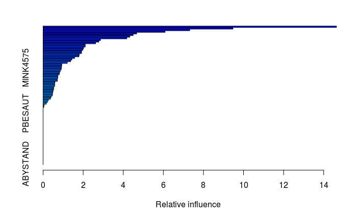

```r
boost_11_sum <- summary(boost_11)
```

The top 6 most important variables:

```r
boost_11_sum[1:6, ]
```

|  | var | rel.inf |
| --- | --- | --- |
| PPERSAUT | PPERSAUT | 14.635048 |
| MKOOPKLA | MKOOPKLA | 9.470916 |
| MOPLHOOG | MOPLHOOG | 7.314574 |
| MBERMIDD | MBERMIDD | 6.086520 |
| PBRAND | PBRAND | 4.667661 |
| MGODGE | MGODGE | 4.494633 |

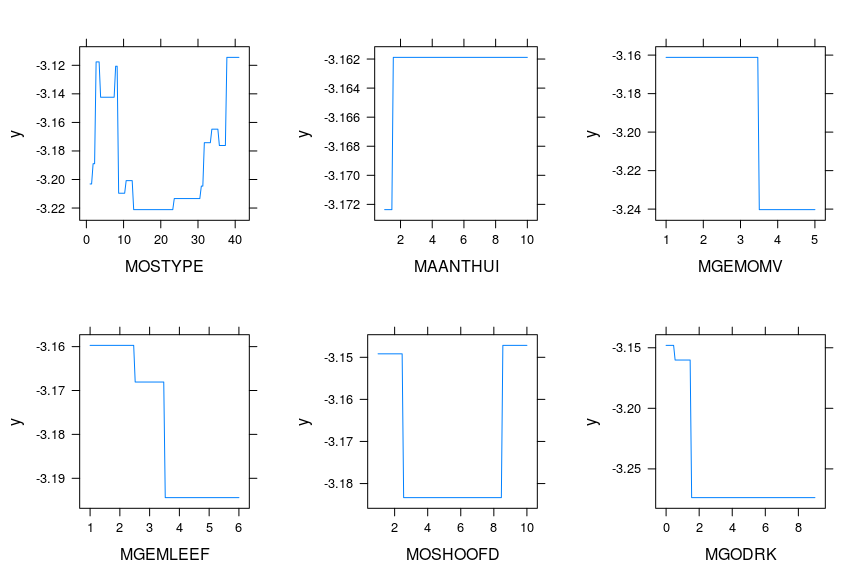

```r
P1 <- map(1:6, ~plot(boost_11, i = names(df)[.x]))
cowplot::plot_grid(plotlist = P1)
```

### (c)

Use the boosting model to predict the response on the test data. Predict that a person will make a purchase if the estimated probability of purchase is greater than 20%:

```r
probs_11 <- predict(boost_11, newdata = df[test, ], n.trees = 1000, type = "response")
preds_11 <- rep(0, length(y[test]))
preds_11[which(probs_11 > 0.2)] <- 1

tab <- table(preds_11, y[test])
tab
```

```
preds_11    0    1
       0 4410  256
       1  123   33
```

Test error (misclassifications):

```r
boost_11.error.test <- (tab[1, 2] + tab[2, 1]) / sum(tab)
#mean(preds_11 != y[test])
boost_11.error.test
```

```
[1] 0.07859809
```

```r
100 * round(sum(y[test]/ length(y[test])), 4)
```

```
[1] 5.99
```

```r
100 * round(boost_11.error.test, 4)
```

```
[1] 7.86
```

Redo the boosting model with a larger training set:

```r
train <- 1:((4*n)/5)
test <- (-train)
boost_11_2 <- gbm(y ~ ., data = df[train, ], shrinkage = 0.01, n.trees = 1000, distribution = "bernoulli")

probs_11_2 <- predict(boost_11_2, newdata = df[test, ], n.trees = 1000, type = "response")
preds_11_2 <- rep(0, length(y[test]))
preds_11_2[which(probs_11_2 > 0.2)] <- 1

tab <- table(preds_11_2, y[test])
tab
```

```
preds_11_2    0    1
         0 1071   66
         1   17   11
```

Test error (misclassifications):

```r
boost_11_2.error.test <- (tab[1, 2] + tab[2, 1]) / sum(tab)
#mean(preds_11 != y[test])
boost_11_2.error.test
```

```
[1] 0.07124464
```

The model trained on a larger portion of the data has a slightly better misclassifiaction rate (7.12% vs 7.86%). But it’s still worse than the null rate of 6.61%.

Full metrics:

```r
caret::confusionMatrix(factor(preds_11_2), factor(y[test]), positive = '1')
```

```
Confusion Matrix and Statistics

          Reference
Prediction    0    1
         0 1071   66
         1   17   11

               Accuracy : 0.9288
                 95% CI : (0.9124, 0.9429)
    No Information Rate : 0.9339
    P-Value [Acc > NIR] : 0.7804

                  Kappa : 0.1806

 Mcnemar's Test P-Value : 1.374e-07

            Sensitivity : 0.142857
            Specificity : 0.984375
         Pos Pred Value : 0.392857
         Neg Pred Value : 0.941953
             Prevalence : 0.066094
         Detection Rate : 0.009442
   Detection Prevalence : 0.024034
      Balanced Accuracy : 0.563616

       'Positive' Class : 1
```

### Logistic Regression

Perform logistic regression using the larger training set:

```r
logreg_11 <- glm(y ~ ., data = df[train, ], family = "binomial")
```

```
glm.fit: fitted probabilities numerically 0 or 1 occurred
```

```r
logreg_11_probs <- predict(logreg_11, newdata = df[test, ], type = "response")
logreg_11_preds <- rep(0, length(y[test]))
logreg_11_preds[which(logreg_11_probs > 0.2)] <- 1
tab <- table(logreg_11_preds, y[test])
tab
```

```
logreg_11_preds    0    1
              0 1055   62
              1   33   15
```

Test error (misclassifications):

```r
logreg_11.error.test <- (tab[1, 2] + tab[2, 1]) / sum(tab)
#mean(preds_11 != y[test])
logreg_11.error.test
```

```
[1] 0.08154506
```

The logistic regression model has a missclassifiaction rate similar to the second boosted model (8.15% vs 7.12%). But it’s still worse than the null rate of 6.61%.

### KNN

Perform KNN using the larger training set:

```r
K <- 1:25
train.X <- as.matrix(df[train, -y])
test.X <- as.matrix(df[test, -y])
train.Y <- y[train]
test.Y <- y[test]
knn_11_preds <- lapply(K, function(x) knn(train.X, test.X, train.Y, k = x))
```

Plot the test error:

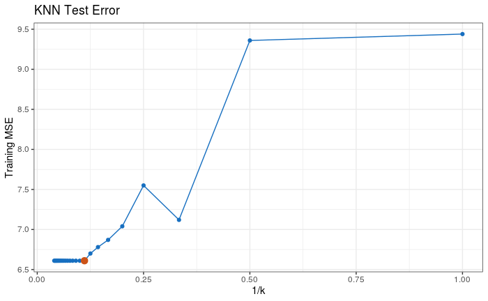

```r
knn.error.rates <- sapply(knn_11_preds, function(x) 100 * (round(1 - mean(x == test.Y), 4)))
k.min <- which.min(knn.error.rates)

data.frame(k = K, error = knn.error.rates) %>%
  ggplot(aes(1/k, error)) +
  geom_line(color = ISLR_blue) +
  geom_point(color = ISLR_blue) +
  geom_point(data = data.frame(x = 1/k.min, y = knn.error.rates[k.min]),
             aes(x, y), color = ISLR_orange, size = 3) +
  labs(x = "1/k", y = "Training MSE",
       title = "KNN Test Error")
```

Minimum error:

```r
knn.error.rates[k.min]
```

```
[1] 6.61
```

KNN produces the minimum error with k = 9; the error is 6.61%. However, the model just predicts no purchase for every observation:

```r
knn_11_preds[k.min][[1]] %>% as.numeric() %>% - 1 %>% sum() # knn preds are all zero
```

```
[1] 0
```

This means that the best KNN models is equivalent to the null model that predicts all zeroes:

```r
knn.error.rates[k.min]
```

```
[1] 6.61
```

```r
round(100 * mean(y[test]), 2) # null rate
```

```
[1] 6.61
```

This also means that the KNN model doesn’t correctly predict any purchases, since it doesn’t predict any purchases at all.

[^1]: James G, Witten D, Hastie T, Tibshirani R (2013). *An Introduction to Statistical Learning: with Applications in R*. Springer, 1st edition.